# 704785772_stats102a_hw1

```r
source('704785772_stats102a_hw1.R')
```

Question 1: Greatest common divisor

gcd function

[figure not shown]

GCD flowchart

FUNCTION gcd(arg1, arg2):

IF arg1 or arg2 contains NA values

PRINT warning message “Variables contain NA value!”

ENDIF

IF arg1 <= 0 or arg2 <= 0

STOP function

PRINT error message “Variables contain 0!”

ENDIF

IF arg1 not integer or arg2 not integer

STOP function

PRINT error message All variables must be integer!"

ENDIF

IF arg1 > arg2

WHILE arg2 != 0

old_arg2 =arg2

arg2 = arg1 %% arg2

arg1 = old_arg2

ENDWHILE

ENDIF

RETURN arg1

IF arg2 > arg1

WHILE arg1 != 0

old_arg1 =arg1

arg1 = arg2 %% arg1

arg2 = old_arg1

ENDWHILE

ENDIF

RETURN arg2

```r
gcd(1071, 462)
```

```
## [1] 21
```

```r
gcd(462, 1071)
```

```
## [1] 21
```

```r
gcd(646, 1406)
```

```
## [1] 38
```

```r
gcd(1, 10)
```

```
## [1] 1
```

```r
try(gcd(0, 12))
```

```
## Error in gcd(0, 12) : Variables contain 0!
```

```r
try(gcd(4.5, 12))
```

```
## Error in gcd(4.5, 12) : All variables must be integer!
```

```r
try(gcd(-1, 12))
```

```
## Error in gcd(-1, 12) : Variables contain 0!
```

gcd_three function

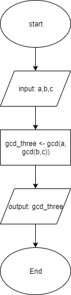

GCD_three flowchart

FUNCTION gcd_3(arg1, arg2, arg3):

CALL gcd(arg2,arg3)

CALL gcd(arg1, gcd(arg2, arg3))

RETURN gcd(arg1, gcd(arg2, arg3))

```r
gcd_3(1071, 462, 4452)
```

```
## [1] 21
```

```r
gcd_3(646, 1406, 4218)
```

```
## [1] 38
```

Question 2: prime factorization

get_factor function

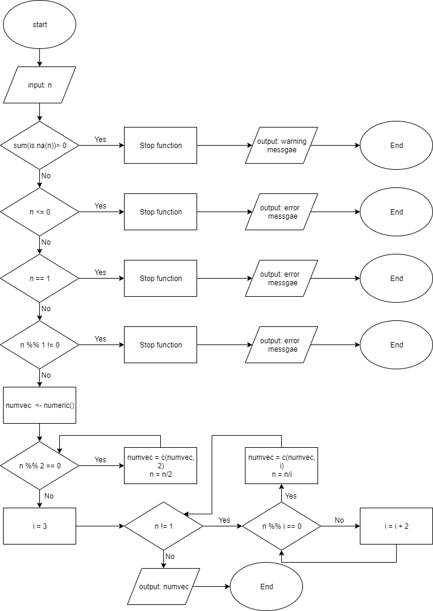

get_factor flowchart

FUNCTION get_factor(arg1):

IF arg1 contains NA values

PRINT warning message “Variables contain NA values!”

ENDIF

IF arg1 <= 0

STOP function

PRINT error message “Input must be a positive number!”

ENDIF

IF arg1 == 1

STOP function

PRINT error message “1 has no prime factorization! Try a larger number!”

ENDIF

IF arg1 not integer

STOP function

PRINT error message “Input must be an integer!”

ENDIF

CREATE an empty numeric vector

WHILE arg1 %% 2 == 0

STORE 2 in the numeric vector

arg1 = arg1 / 2

ENDWHILE

CREATE a double variable i and ASSIGN i = 3

WHILE arg1 != 1

WHILE n %% i == 0

STORE i in the numeric vector

ENDWHILE

i = i + 2

ENDWHILE

RETURN the numeric vector

```r
get_factor(12)
```

```
## [1] 2 2 3
```

```r
get_factor(1800)
```

```
## [1] 2 2 2 3 3 5 5
```

```r
get_factor(32851)
```

```
## [1]  7 13 19 19
```

```r
get_factor(9587)
```

```
## [1] 9587
```

```r
try(get_factor(-280))
```

```
## Error in get_factor(-280) : Input must be a positive number!
```

```r
try(get_factor(280.75))
```

```
## Error in get_factor(280.75) : Input must be an integer!
```

is_prime function

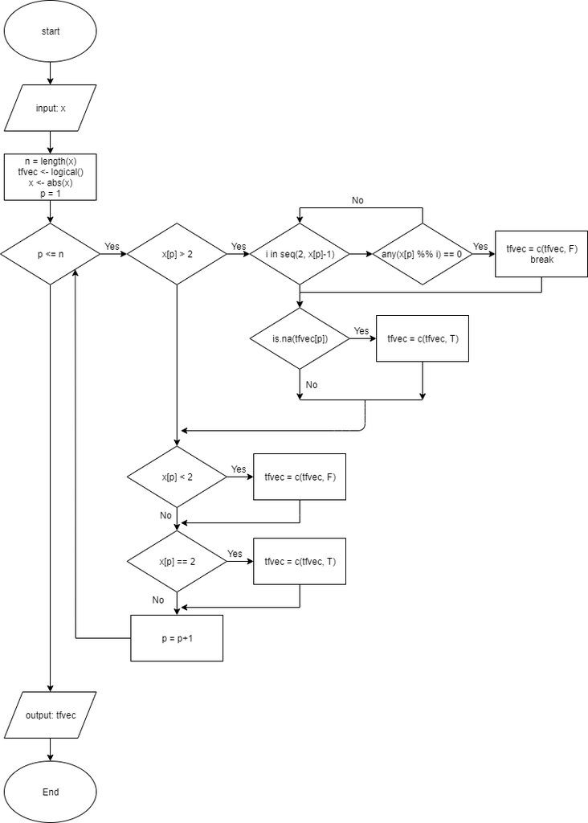

is_prime flowchart

FUNCTION is_prime(arg1):

ASSIGN n = length(arg1)

CREATE a logical vector tfvec

FIND ABSOLUTE values of components of arg1 and Assign arg1 to the ABSOLUTE values

ASSIGN index p = 1

WHILE index p <= length of arg1 n

IF pth element in arg1 > 2

FOR i in [2, (pth element in arg1 - 1)]

IF ANY(pth element of arg1 %% i = 0)

STORE a F in logical vector tfvec as pth element

BREAK from FORLOOP

ENDIF

ENDFOR

IF pth element of tfvec empty

STORE a T in logical vector tfvec as pth element

ENDIF

IF pth element in arg1 < 2

STORE a F in logical vector tfvec as pth element

ENDIF

IF pth element in arg1 == 2

STORE a T in logical vector tfvec as pth element

ENDIF

p = p + 1

ENDWHILE

RETURN tfvec

```r
is_prime(9)
```

```
## [1] FALSE
```

```r
is_prime(c(2, 97, 23, 51, 119, -1, 0, 1.5))
```

```
## [1]  TRUE  TRUE  TRUE FALSE FALSE FALSE FALSE FALSE
```